# Energy SVAR Analysis

Alessandro Macchi

2026-06-19

This notebook is the readable report layer for the thesis SVAR project.

The reusable code lives in `R/`. The most important file for experimentation is `R/02_variable_catalogue.R`: when a new candidate variable is added, its raw file, raw column, active model variant, role, and current SVAR order should be described there first.

## 1. Variable Catalogue

This catalogue is the central place where candidate variables and the current experiment are described.

To quickly try another specification, change:

- `model_variant`: `level`, `log`, `d_level`, or `d_log`;
- `role`: `endogenous`, `exogenous`, or `unused`;
- `svar_order`: Cholesky order, only for endogenous variables.

```r
catalogue_view <- describe_variable_catalogue(variable_catalogue)
compact_table(catalogue_view)
```

| variable_id | file | display_name | model_variant | active_model_column | role | svar_order |
| --- | --- | --- | --- | --- | --- | --- |
| pun | pun.csv | PUN | d_log | d_log_pun | endogenous | 4 |
| natural_gas | natural_gas.csv | Natural gas | log | log_natural_gas | endogenous | 2 |
| res_capacity | italy_res_capacity_monthly.csv | RES capacity | d_log | d_log_res_capacity | endogenous | 1 |
| heating_degree_days | hdd.csv | Heating degree days | level | heating_degree_days | exogenous | NA |
| cooling_degree_days | cdd.csv | Cooling degree days | level | cooling_degree_days | exogenous | NA |
| electricity_consumption | energy_consumption.csv | Electricity consumption | d_log | d_log_electricity_consumption | endogenous | 3 |

## 2. Load The Data

The raw monthly series are loaded using the catalogue. This avoids one hard-coded `read.csv()` call per variable in the notebook.

```r
all_data <- load_catalogue_data(variable_catalogue)

data_coverage <- summarise_data_coverage(all_data)
compact_table(data_coverage)
```

| variable | start | end | observations | missing_values |
| --- | --- | --- | --- | --- |
| Cooling degree days | 2000-01-01 | 2025-12-01 | 312 | 0 |
| Electricity consumption | 2004-04-01 | 2026-06-01 | 267 | 0 |
| Heating degree days | 2000-01-01 | 2025-12-01 | 312 | 0 |
| Natural gas | 1960-01-01 | 2026-05-01 | 797 | 0 |
| PUN | 2004-04-01 | 2026-06-01 | 267 | 0 |
| RES capacity | 2005-01-01 | 2025-12-01 | 252 | 0 |

## 3. Keep The Common Monthly Sample

For a VAR or SVAR, all variables need to be observed over the same dates. The current common sample is from January 2005 to December 2025.

I also exclude 2026 here because the June 2026 electricity consumption observation looks incomplete.

```r
prepared_data <- prepare_candidate_data(
  all_data,
  catalogue = variable_catalogue,
  config = experiment_config
)

plot_data <- prepared_data$plot_data
svar_data <- prepared_data$svar_data

sample_counts <- summarise_sample_counts(plot_data)
compact_table(sample_counts)
```

| variable | observations |
| --- | --- |
| Cooling degree days | 252 |
| Electricity consumption | 252 |
| Heating degree days | 252 |
| Natural gas | 252 |
| PUN | 252 |
| RES capacity | 252 |

## 4. Variables In Levels

This section looks at the original variables.

For each variable, we plot:

- the time series;
- the ACF;
- the PACF.

If the time series has a clear trend, or if the ACF decays very slowly, the variable may not be stationary in levels.

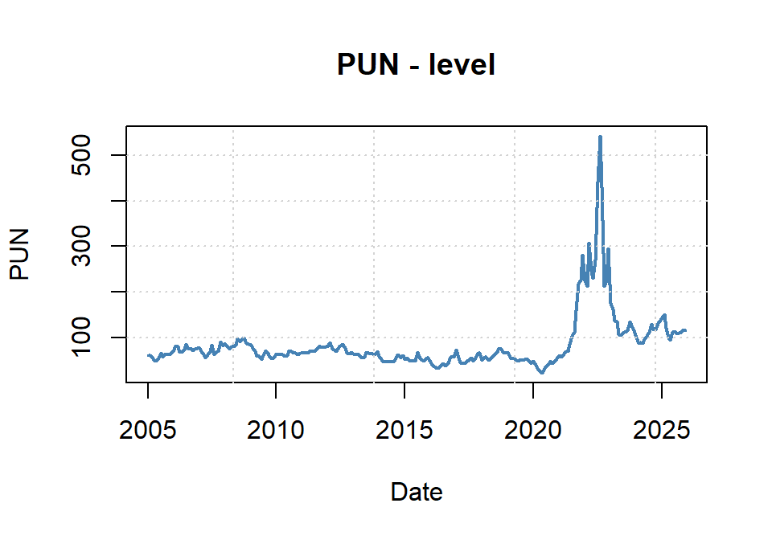

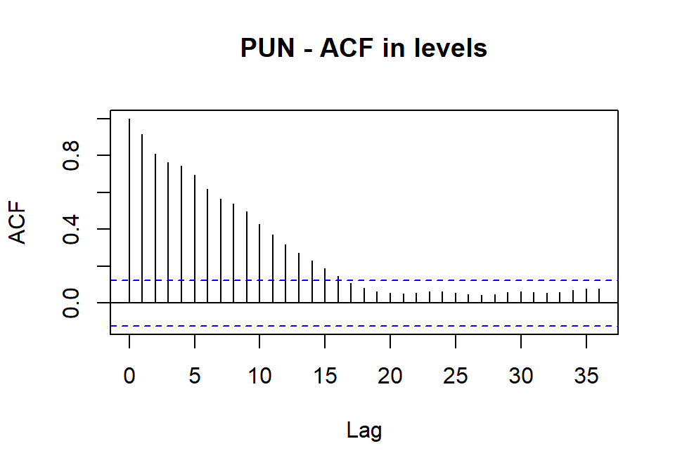

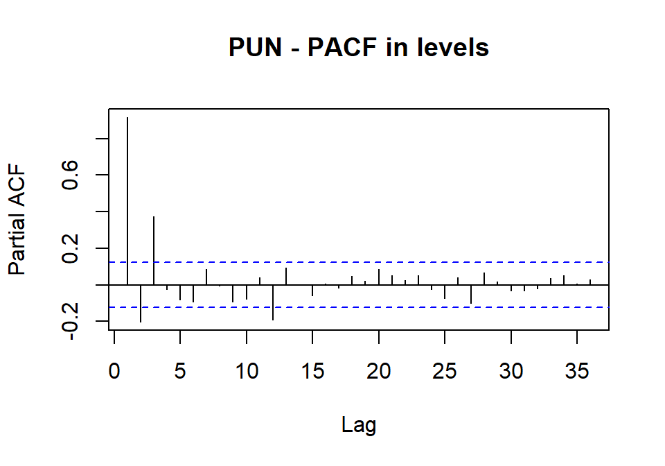

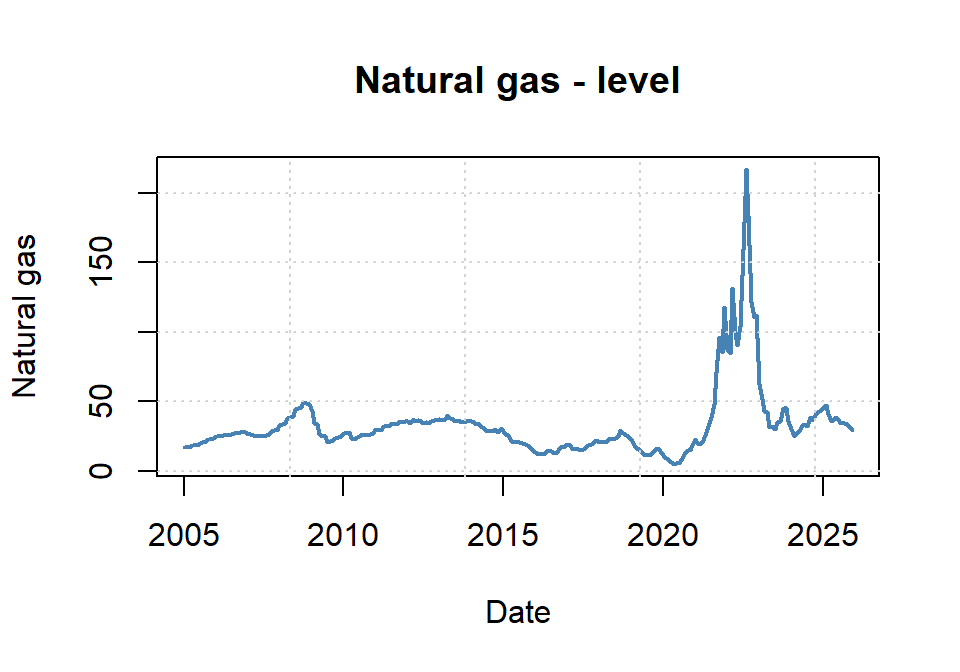

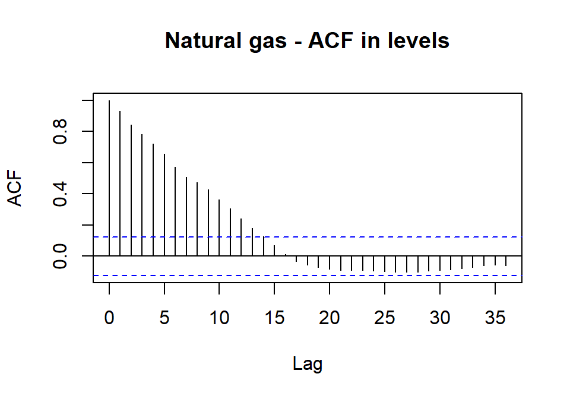

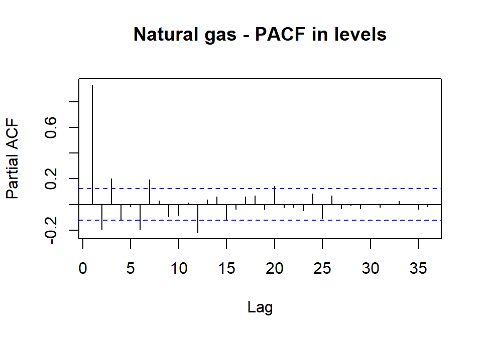

[figure not shown]

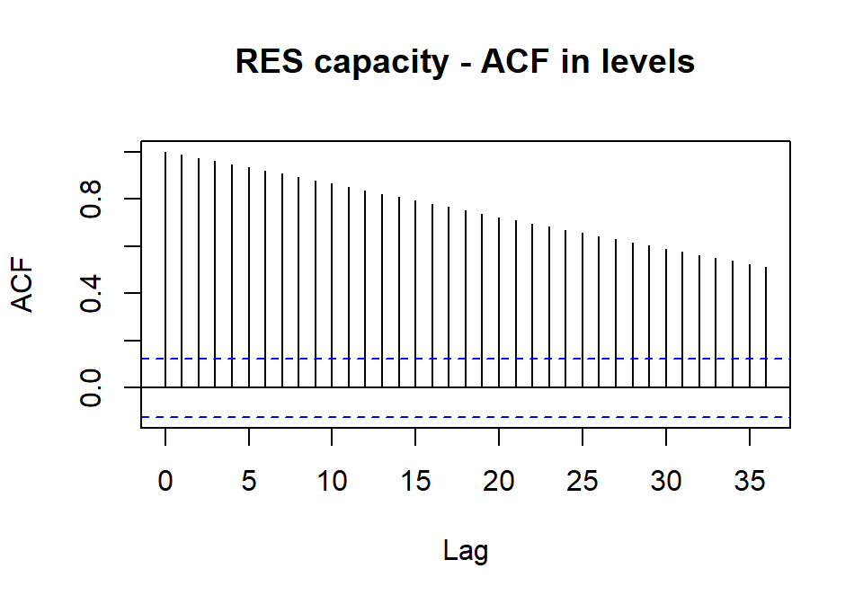

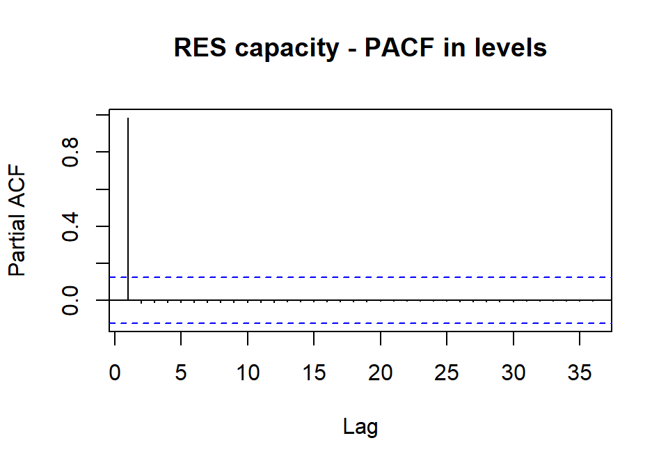

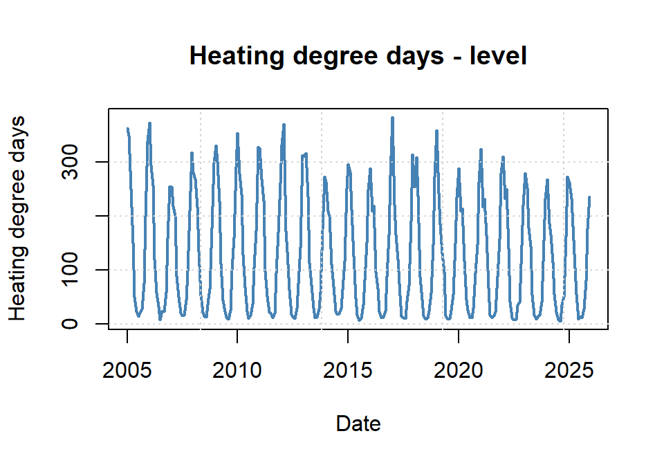

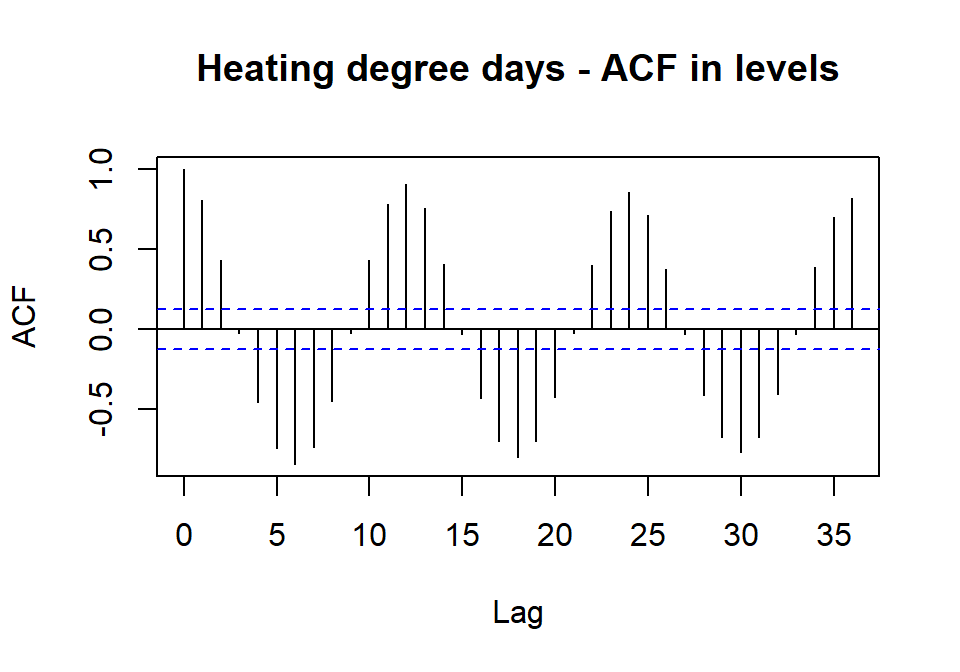

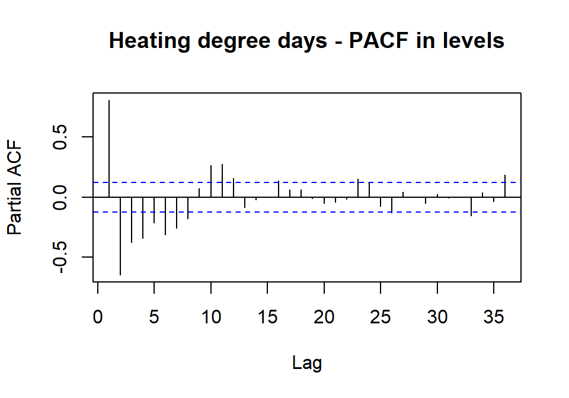

[6 more figures not shown]

```r
plot_level_diagnostics(plot_data)
```

## 5. Preliminary Transformations

This step prepares a first dataset for the SVAR analysis.

The current experiment uses the `model_variant` selected in the catalogue. Monthly dummies are also added, using January as the reference month.

```r
transformation_plan <- describe_variable_catalogue(variable_catalogue)

compact_table(transformation_plan)
```

| variable_id | file | display_name | model_variant | active_model_column | role | svar_order |
| --- | --- | --- | --- | --- | --- | --- |
| pun | pun.csv | PUN | d_log | d_log_pun | endogenous | 4 |
| natural_gas | natural_gas.csv | Natural gas | log | log_natural_gas | endogenous | 2 |
| res_capacity | italy_res_capacity_monthly.csv | RES capacity | d_log | d_log_res_capacity | endogenous | 1 |
| heating_degree_days | hdd.csv | Heating degree days | level | heating_degree_days | exogenous | NA |
| cooling_degree_days | cdd.csv | Cooling degree days | level | cooling_degree_days | exogenous | NA |
| electricity_consumption | energy_consumption.csv | Electricity consumption | d_log | d_log_electricity_consumption | endogenous | 3 |

```r
preview_columns <- c("Date", get_active_model_columns(variable_catalogue))
compact_table(head(svar_data[, preview_columns]))
```

| Date | d_log_pun | log_natural_gas | d_log_res_capacity | heating_degree_days | cooling_degree_days | d_log_electricity_consumption |
| --- | --- | --- | --- | --- | --- | --- |
| 2005-01-01 | NA | 2.829478 | NA | 362.94115 | 0.0000000 | NA |
| 2005-02-01 | -0.0207669 | 2.834958 | 0.0009486 | 349.54881 | 0.0000000 | -0.0295293 |
| 2005-03-01 | -0.0548125 | 2.840407 | 0.0009477 | 250.28539 | 0.0829124 | 0.0720117 |
| 2005-04-01 | -0.1481220 | 2.900179 | 0.0009473 | 149.86278 | 0.3383810 | -0.0846093 |
| 2005-05-01 | -0.0306932 | 2.905286 | 0.0009459 | 49.02036 | 9.4754431 | 0.0201276 |
| 2005-06-01 | 0.1469226 | 2.908675 | 0.0009455 | 22.60915 | 40.3972753 | 0.0217379 |

## 6. ADF Stationarity Tests

The Augmented Dickey-Fuller test has this null hypothesis:

- the variable has a unit root, so it is not stationary.

If the p-value is below 0.05, we reject the null and treat the variable as stationary. This is still a preliminary check, not the final modelling decision. I use 12 lags because the data are monthly.

```r
adf_variables <- get_catalogue_model_columns(variable_catalogue)

adf_results <- run_adf_tests(
  svar_data,
  variables = adf_variables,
  lags = experiment_config$adf_lag
)

compact_table(adf_results)
```

| variable | lags | adf_statistic | p_value | conclusion |
| --- | --- | --- | --- | --- |
| d_log_pun | 12 | -3.571877 | 0.0363580 | Reject unit root: stationary |
| log_natural_gas | 12 | -3.897386 | 0.0146287 | Reject unit root: stationary |
| d_log_res_capacity | 12 | -2.572381 | 0.3347869 | Do not reject unit root: non-stationary |
| heating_degree_days | 12 | -3.252198 | 0.0796310 | Do not reject unit root: non-stationary |
| cooling_degree_days | 12 | -3.496807 | 0.0435724 | Reject unit root: stationary |
| d_log_electricity_consumption | 12 | -5.436096 | 0.0100000 | Reject unit root: stationary |

## 7. First Differences For Active Differenced Variables

The previous ADF test suggests that some logged variables may still be non-stationary. As a next preliminary step, I inspect the active catalogue variables whose `model_variant` is `d_level` or `d_log`.

```r
diff_variables <- get_difference_columns(variable_catalogue)

diff_adf_results <- run_adf_tests(
  svar_data,
  variables = diff_variables,
  lags = experiment_config$adf_lag
)

compact_table(diff_adf_results)
```

| variable | lags | adf_statistic | p_value | conclusion |
| --- | --- | --- | --- | --- |
| d_log_pun | 12 | -3.571877 | 0.0363580 | Reject unit root: stationary |
| d_log_res_capacity | 12 | -2.572381 | 0.3347869 | Do not reject unit root: non-stationary |
| d_log_electricity_consumption | 12 | -5.436096 | 0.0100000 | Reject unit root: stationary |

## 8. Structural VAR With Cholesky Identification

This section estimates the current baseline SVAR.

The current Cholesky ordering is read from `svar_order` in the catalogue.

The variables marked as exogenous in the catalogue, plus monthly dummies, enter as external regressors. In the recursive forecast exercise, their realised values are used for the next month, so the exercise is conditional on these exogenous paths.

```r
svar_variables <- get_svar_variables(variable_catalogue)
exogenous_variables <- get_exogenous_variables(
  svar_data,
  catalogue = variable_catalogue,
  include_month_dummies = experiment_config$include_month_dummies
)

svar_input <- build_svar_input(
  svar_data,
  catalogue = variable_catalogue,
  config = experiment_config
)

model_samples <- make_model_samples(
  svar_input,
  svar_variables = svar_variables,
  exogenous_variables = exogenous_variables,
  config = experiment_config
)

estimation_sample <- model_samples$estimation_sample
test_sample <- model_samples$test_sample
endog_estimation <- model_samples$endog_estimation
exog_estimation <- model_samples$exog_estimation

model_variable_table <- make_model_variable_table(
  svar_variables,
  exogenous_variables
)

compact_table(model_variable_table)
```

| block | variable |
| --- | --- |
| endogenous | d_log_res_capacity |
| endogenous | log_natural_gas |
| endogenous | d_log_electricity_consumption |
| endogenous | d_log_pun |
| exogenous | heating_degree_days |
| exogenous | cooling_degree_days |
| exogenous | month_Feb |
| exogenous | month_Mar |
| exogenous | month_Apr |
| exogenous | month_May |
| exogenous | month_Jun |
| exogenous | month_Jul |
| exogenous | month_Aug |
| exogenous | month_Sep |
| exogenous | month_Oct |
| exogenous | month_Nov |
| exogenous | month_Dec |

```r
sample_sizes <- summarise_sample_sizes(estimation_sample, test_sample)
compact_table(sample_sizes)
```

| sample | start | end | observations |
| --- | --- | --- | --- |
| estimation | 2005-02-01 | 2021-08-01 | 199 |
| test | 2021-09-01 | 2025-12-01 | 52 |

## 9. Lag Selection And Reduced-Form VAR

The information criteria are reported using `VARselect()` with `lag.max = 12`. For this baseline, I keep 12 lags to allow annual seasonality in monthly data.

```r
lag_selection <- select_var_lags(
  endog = endog_estimation,
  exog = exog_estimation,
  lag_max = experiment_config$lag_max
)

# compact_table(lag_selection$criteria_table)

selected_lag <- experiment_config$selected_lag
compact_table(data.frame(selected_lag = selected_lag))
```

| selected_lag |
| --- |
| 12 |

```r
var_fit <- fit_reduced_form_var(
  endog = endog_estimation,
  exog = exog_estimation,
  selected_lag = selected_lag
)

var_diagnostics <- summarise_var_diagnostics(var_fit, selected_lag)
compact_table(var_diagnostics)
```

| test | statistic | df | p_value | decision_5pct |
| --- | --- | --- | --- | --- |
| Portmanteau | 221.289 | 192 | 0.07240 | do not reject H0 |
| Ljung-Box: d_log_res_capacity | 11.012 | 24 | 0.98900 | do not reject H0 |
| Ljung-Box: log_natural_gas | 12.176 | 24 | 0.97800 | do not reject H0 |
| Ljung-Box: d_log_electricity_consumption | 19.018 | 24 | 0.75100 | do not reject H0 |
| Ljung-Box: d_log_pun | 30.190 | 24 | 0.17900 | do not reject H0 |
| Jarque-Bera | 12212.474 | 8 | 0.00000 | reject H0 |
| ARCH | 587.710 | 500 | 0.00406 | reject H0 |

```r
# summary(var_fit)
```

## 10. Cholesky A-Matrix And SVAR Estimation

For an A-model in `vars::SVAR()`, the `NA` entries are estimated and the numeric entries are restrictions.

For recursive Cholesky identification, exact identification requires `K * (K - 1) / 2` zero restrictions above the diagonal. The helper below checks this for the currently selected endogenous block.

```r
amat <- make_cholesky_amat(svar_variables)
identification_check <- check_cholesky_identification(amat)

amat
```

```
#>                               d_log_res_capacity log_natural_gas
#> d_log_res_capacity                            NA               0
#> log_natural_gas                               NA              NA
#> d_log_electricity_consumption                 NA              NA
#> d_log_pun                                     NA              NA
#>                               d_log_electricity_consumption d_log_pun
#> d_log_res_capacity                                        0         0
#> log_natural_gas                                           0         0
#> d_log_electricity_consumption                            NA         0
#> d_log_pun                                                NA        NA
```

```r
compact_table(identification_check)
```

| k_endog | needed_zero_restrictions | imposed_zero_restrictions | free_lower_off_diagonal_parameters | exactly_identified |
| --- | --- | --- | --- | --- |
| 4 | 6 | 6 | 6 | TRUE |

```r
svar_fit <- fit_svar_cholesky(var_fit, amat)
svar_fit$A
```

```
#>                               d_log_res_capacity log_natural_gas
#> d_log_res_capacity                     93.562842        0.000000
#> log_natural_gas                         5.335606       12.651946
#> d_log_electricity_consumption          -3.215579       -1.887536
#> d_log_pun                              -4.333452       -4.548139
#>                               d_log_electricity_consumption d_log_pun
#> d_log_res_capacity                                  0.00000   0.00000
#> log_natural_gas                                     0.00000   0.00000
#> d_log_electricity_consumption                      36.81081   0.00000
#> d_log_pun                                         -13.44289  12.94709
```

## 11. Recursive One-Step PUN Forecast Evaluation

For point forecasts, the SVAR and the reduced-form VAR imply the same conditional mean. The recursive exercise therefore re-estimates the reduced-form VAR each month and then converts the one-step PUN forecasts back to levels.

The random walk benchmark is:

- next PUN level equals the last observed PUN level.

The Clark-West test compares the squared forecast errors of the SVAR and the random walk with a nesting adjustment. The null hypothesis is equal predictive accuracy.

```r
recursive_forecasts <- run_recursive_forecasts(
  data = svar_input,
  svar_variables = svar_variables,
  exogenous_variables = exogenous_variables,
  selected_lag = selected_lag,
  catalogue = variable_catalogue,
  config = experiment_config
)

pun_forecast_accuracy <- forecast_accuracy_table(
  recursive_forecasts,
  target_name = experiment_config$forecast_target_name
)

compact_table(pun_forecast_accuracy)
```

| variable | rmse_svar | rmse_rw | mae_svar | mae_rw | theils_u | clark_west_statistic | clark_west_p_value_one_sided |
| --- | --- | --- | --- | --- | --- | --- | --- |
| pun | 52.86916 | 54.07399 | 33.62888 | 30.52661 | 0.9777188 | 1.537892 | 0.0620376 |